# Risk Factor Analysis

## Outcome Variable

**Outcome Variable:** wasted

## Predictor Variables

**Intervention Variable:** impsan

**Adjustment Set:**

- arm
- sex
- W_mage
- meducyrs
- feducyrs
- hhwealth_quart
- hfoodsec
- W_mhtcm
- W_mwtkg
- W_mbmi
- W_nrooms
- W_nchldlt5
- W_parity
- impfloor
- safeh20
- delta_W_mage
- delta_meducyrs
- delta_feducyrs
- delta_hhwealth_quart
- delta_hfoodsec
- delta_W_mhtcm
- delta_W_mwtkg
- delta_W_mbmi
- delta_W_nrooms
- delta_W_nchldlt5
- delta_W_parity
- delta_impfloor
- delta_safeh20

## Stratifying Variables

The analysis was stratified on these variable(s):

- agecat
- studyid
- country

## Data Summary

| agecat | studyid | country | impsan | wasted | n_cell | n |
| --- | --- | --- | --- | --- | --- | --- |
| Birth | ki0047075b-MAL-ED | BANGLADESH | 1 | 0 | 138 | 201 |
| Birth | ki0047075b-MAL-ED | BANGLADESH | 1 | 1 | 30 | 201 |
| Birth | ki0047075b-MAL-ED | BANGLADESH | 0 | 0 | 28 | 201 |
| Birth | ki0047075b-MAL-ED | BANGLADESH | 0 | 1 | 5 | 201 |
| Birth | ki0047075b-MAL-ED | BRAZIL | 1 | 0 | 54 | 57 |
| Birth | ki0047075b-MAL-ED | BRAZIL | 1 | 1 | 2 | 57 |
| Birth | ki0047075b-MAL-ED | BRAZIL | 0 | 0 | 1 | 57 |
| Birth | ki0047075b-MAL-ED | BRAZIL | 0 | 1 | 0 | 57 |
| Birth | ki0047075b-MAL-ED | INDIA | 1 | 0 | 11 | 39 |
| Birth | ki0047075b-MAL-ED | INDIA | 1 | 1 | 3 | 39 |
| Birth | ki0047075b-MAL-ED | INDIA | 0 | 0 | 23 | 39 |
| Birth | ki0047075b-MAL-ED | INDIA | 0 | 1 | 2 | 39 |
| Birth | ki0047075b-MAL-ED | NEPAL | 1 | 0 | 22 | 25 |
| Birth | ki0047075b-MAL-ED | NEPAL | 1 | 1 | 2 | 25 |
| Birth | ki0047075b-MAL-ED | NEPAL | 0 | 0 | 1 | 25 |
| Birth | ki0047075b-MAL-ED | NEPAL | 0 | 1 | 0 | 25 |
| Birth | ki0047075b-MAL-ED | PERU | 1 | 0 | 50 | 203 |
| Birth | ki0047075b-MAL-ED | PERU | 1 | 1 | 0 | 203 |
| Birth | ki0047075b-MAL-ED | PERU | 0 | 0 | 149 | 203 |
| Birth | ki0047075b-MAL-ED | PERU | 0 | 1 | 4 | 203 |
| Birth | ki0047075b-MAL-ED | SOUTH AFRICA | 1 | 0 | 0 | 94 |
| Birth | ki0047075b-MAL-ED | SOUTH AFRICA | 1 | 1 | 0 | 94 |
| Birth | ki0047075b-MAL-ED | SOUTH AFRICA | 0 | 0 | 84 | 94 |
| Birth | ki0047075b-MAL-ED | SOUTH AFRICA | 0 | 1 | 10 | 94 |
| Birth | ki0047075b-MAL-ED | TANZANIA, UNITED REPUBLIC OF | 1 | 0 | 0 | 110 |
| Birth | ki0047075b-MAL-ED | TANZANIA, UNITED REPUBLIC OF | 1 | 1 | 0 | 110 |
| Birth | ki0047075b-MAL-ED | TANZANIA, UNITED REPUBLIC OF | 0 | 0 | 109 | 110 |
| Birth | ki0047075b-MAL-ED | TANZANIA, UNITED REPUBLIC OF | 0 | 1 | 1 | 110 |
| Birth | ki1017093-NIH-Birth | BANGLADESH | 1 | 0 | 157 | 575 |
| Birth | ki1017093-NIH-Birth | BANGLADESH | 1 | 1 | 65 | 575 |

[output cut: 170 more lines]

The following strata were considered:

- agecat: 24 months, studyid: ki0047075b-MAL-ED, country: BANGLADESH
- agecat: 24 months, studyid: ki0047075b-MAL-ED, country: BRAZIL
- agecat: 24 months, studyid: ki0047075b-MAL-ED, country: INDIA
- agecat: 24 months, studyid: ki0047075b-MAL-ED, country: NEPAL
- agecat: 24 months, studyid: ki0047075b-MAL-ED, country: PERU
- agecat: 24 months, studyid: ki0047075b-MAL-ED, country: SOUTH AFRICA
- agecat: 24 months, studyid: ki0047075b-MAL-ED, country: TANZANIA, UNITED REPUBLIC OF
- agecat: 24 months, studyid: ki1017093-NIH-Birth, country: BANGLADESH
- agecat: 24 months, studyid: ki1017093b-PROVIDE, country: BANGLADESH
- agecat: 24 months, studyid: ki1017093c-NIH-Crypto, country: BANGLADESH
- agecat: 24 months, studyid: ki1114097-CONTENT, country: PERU
- agecat: 24 months, studyid: ki1135781-COHORTS, country: GUATEMALA
- agecat: 24 months, studyid: ki1135781-COHORTS, country: INDIA
- agecat: 24 months, studyid: ki1135781-COHORTS, country: PHILIPPINES
- agecat: 24 months, studyid: ki1148112-LCNI-5, country: MALAWI
- agecat: 24 months, studyid: kiGH5241-JiVitA-3, country: BANGLADESH
- agecat: 24 months, studyid: kiGH5241-JiVitA-4, country: BANGLADESH
- agecat: 6 months, studyid: ki0047075b-MAL-ED, country: BANGLADESH
- agecat: 6 months, studyid: ki0047075b-MAL-ED, country: BRAZIL
- agecat: 6 months, studyid: ki0047075b-MAL-ED, country: INDIA
- agecat: 6 months, studyid: ki0047075b-MAL-ED, country: NEPAL
- agecat: 6 months, studyid: ki0047075b-MAL-ED, country: PERU
- agecat: 6 months, studyid: ki0047075b-MAL-ED, country: SOUTH AFRICA
- agecat: 6 months, studyid: ki0047075b-MAL-ED, country: TANZANIA, UNITED REPUBLIC OF
- agecat: 6 months, studyid: ki1017093-NIH-Birth, country: BANGLADESH
- agecat: 6 months, studyid: ki1017093b-PROVIDE, country: BANGLADESH
- agecat: 6 months, studyid: ki1017093c-NIH-Crypto, country: BANGLADESH
- agecat: 6 months, studyid: ki1114097-CONTENT, country: PERU
- agecat: 6 months, studyid: ki1135781-COHORTS, country: GUATEMALA
- agecat: 6 months, studyid: ki1135781-COHORTS, country: INDIA
- agecat: 6 months, studyid: ki1135781-COHORTS, country: PHILIPPINES
- agecat: 6 months, studyid: ki1148112-LCNI-5, country: MALAWI
- agecat: 6 months, studyid: kiGH5241-JiVitA-3, country: BANGLADESH
- agecat: 6 months, studyid: kiGH5241-JiVitA-4, country: BANGLADESH
- agecat: Birth, studyid: ki0047075b-MAL-ED, country: BANGLADESH
- agecat: Birth, studyid: ki0047075b-MAL-ED, country: BRAZIL
- agecat: Birth, studyid: ki0047075b-MAL-ED, country: INDIA
- agecat: Birth, studyid: ki0047075b-MAL-ED, country: NEPAL
- agecat: Birth, studyid: ki0047075b-MAL-ED, country: PERU
- agecat: Birth, studyid: ki0047075b-MAL-ED, country: SOUTH AFRICA
- agecat: Birth, studyid: ki0047075b-MAL-ED, country: TANZANIA, UNITED REPUBLIC OF
- agecat: Birth, studyid: ki1017093-NIH-Birth, country: BANGLADESH
- agecat: Birth, studyid: ki1017093b-PROVIDE, country: BANGLADESH
- agecat: Birth, studyid: ki1017093c-NIH-Crypto, country: BANGLADESH
- agecat: Birth, studyid: ki1114097-CONTENT, country: PERU
- agecat: Birth, studyid: ki1135781-COHORTS, country: GUATEMALA
- agecat: Birth, studyid: ki1135781-COHORTS, country: INDIA
- agecat: Birth, studyid: ki1135781-COHORTS, country: PHILIPPINES
- agecat: Birth, studyid: kiGH5241-JiVitA-3, country: BANGLADESH
- agecat: Birth, studyid: kiGH5241-JiVitA-4, country: BANGLADESH

### Dropped Strata

Some strata were dropped due to rare outcomes:

- agecat: Birth, studyid: ki0047075b-MAL-ED, country: BRAZIL
- agecat: Birth, studyid: ki0047075b-MAL-ED, country: INDIA
- agecat: Birth, studyid: ki0047075b-MAL-ED, country: NEPAL
- agecat: Birth, studyid: ki0047075b-MAL-ED, country: PERU
- agecat: Birth, studyid: ki0047075b-MAL-ED, country: SOUTH AFRICA
- agecat: Birth, studyid: ki0047075b-MAL-ED, country: TANZANIA, UNITED REPUBLIC OF
- agecat: Birth, studyid: ki1017093b-PROVIDE, country: BANGLADESH
- agecat: Birth, studyid: ki1114097-CONTENT, country: PERU
- agecat: 6 months, studyid: ki0047075b-MAL-ED, country: BANGLADESH
- agecat: 6 months, studyid: ki0047075b-MAL-ED, country: BRAZIL
- agecat: 6 months, studyid: ki0047075b-MAL-ED, country: NEPAL
- agecat: 6 months, studyid: ki0047075b-MAL-ED, country: PERU
- agecat: 6 months, studyid: ki0047075b-MAL-ED, country: SOUTH AFRICA
- agecat: 6 months, studyid: ki0047075b-MAL-ED, country: TANZANIA, UNITED REPUBLIC OF
- agecat: 6 months, studyid: ki1017093b-PROVIDE, country: BANGLADESH
- agecat: 6 months, studyid: ki1114097-CONTENT, country: PERU
- agecat: 6 months, studyid: ki1135781-COHORTS, country: GUATEMALA
- agecat: 6 months, studyid: ki1135781-COHORTS, country: PHILIPPINES
- agecat: 6 months, studyid: ki1148112-LCNI-5, country: MALAWI
- agecat: 24 months, studyid: ki0047075b-MAL-ED, country: BRAZIL
- agecat: 24 months, studyid: ki0047075b-MAL-ED, country: NEPAL
- agecat: 24 months, studyid: ki0047075b-MAL-ED, country: PERU
- agecat: 24 months, studyid: ki0047075b-MAL-ED, country: SOUTH AFRICA
- agecat: 24 months, studyid: ki0047075b-MAL-ED, country: TANZANIA, UNITED REPUBLIC OF
- agecat: 24 months, studyid: ki1017093b-PROVIDE, country: BANGLADESH
- agecat: 24 months, studyid: ki1017093c-NIH-Crypto, country: BANGLADESH
- agecat: 24 months, studyid: ki1114097-CONTENT, country: PERU
- agecat: 24 months, studyid: ki1135781-COHORTS, country: GUATEMALA
- agecat: 24 months, studyid: ki1148112-LCNI-5, country: MALAWI

## Methods Detail

We’re interested in the causal parameters $E[Y_a]$ for all values of $a \in \mathcal{A}$. These parameters represent the mean outcome if, possibly contrary to fact, we intervened to set all units to have $A=a$. Under the randomization and positivity assumptions, these are identified by the statistical parameters $\psi_a=E_W[E_{Y|A,W}(Y|A=a,W)]$. In addition, we’re interested in the mean of $Y$, $E[Y]$ under no intervention (the observed mean). We will estimate these parameters by using SuperLearner to fit the relevant likelihood factors – $E_{Y|A,W}(Y|A=a,W)$ and $p(A=a|W)$, and then updating our likelihood fit using a joint TMLE.

For unadjusted analyses ($W=\{\}$), initial likelihoods were estimated using Lrnr_glm to estimate the simple $E(Y|A)$ and Lrnr_mean to estimate $p(A)$. For adjusted analyses, a small library containing Lrnr_glmnet, Lrnr_xgboost, and Lrnr_mean was used.

Having estimated these parameters, we will then use the delta method to estimate relative risks and attributable risks relative to a prespecified baseline level of $A$.

# Results Detail

## Results Plots

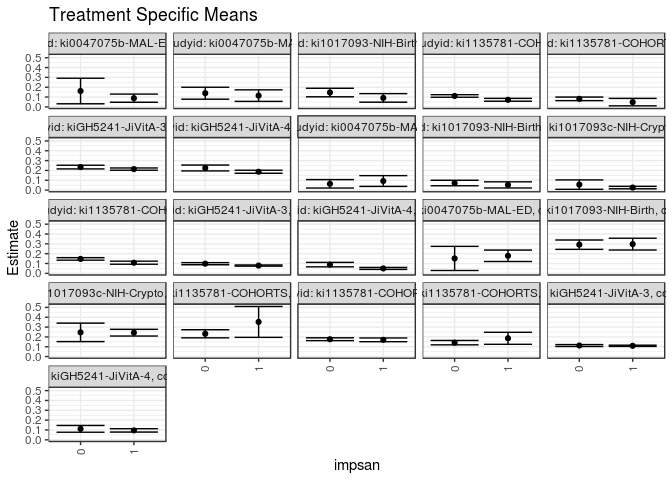

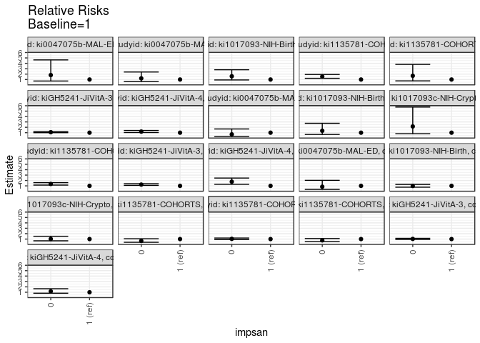

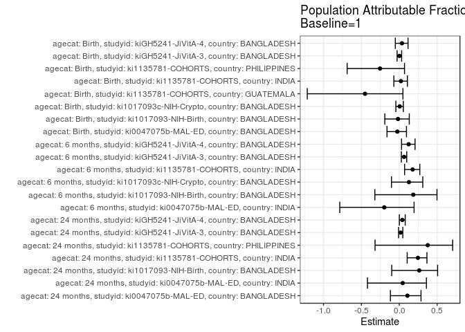

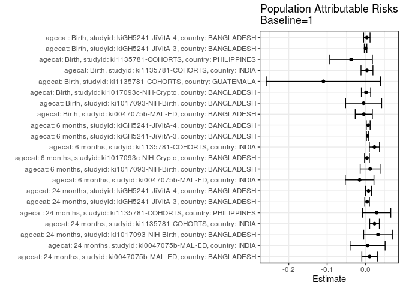

## Results Table

### Parameter: TSM

| agecat | studyid | country | intervention_level | baseline_level | estimate | ci_lower | ci_upper |
| --- | --- | --- | --- | --- | --- | --- | --- |
| Birth | ki0047075b-MAL-ED | BANGLADESH | 1 | NA | 0.1785714 | 0.1205127 | 0.2366301 |
| Birth | ki0047075b-MAL-ED | BANGLADESH | 0 | NA | 0.1515152 | 0.0288774 | 0.2741529 |
| Birth | ki1017093-NIH-Birth | BANGLADESH | 1 | NA | 0.2970699 | 0.2371519 | 0.3569879 |
| Birth | ki1017093-NIH-Birth | BANGLADESH | 0 | NA | 0.2914688 | 0.2439771 | 0.3389604 |
| Birth | ki1017093c-NIH-Crypto | BANGLADESH | 1 | NA | 0.2428905 | 0.2088474 | 0.2769336 |
| Birth | ki1017093c-NIH-Crypto | BANGLADESH | 0 | NA | 0.2461285 | 0.1522999 | 0.3399571 |
| Birth | ki1135781-COHORTS | GUATEMALA | 1 | NA | 0.3524174 | 0.1954225 | 0.5094124 |
| Birth | ki1135781-COHORTS | GUATEMALA | 0 | NA | 0.2317905 | 0.1906405 | 0.2729406 |
| Birth | ki1135781-COHORTS | INDIA | 1 | NA | 0.1701377 | 0.1511659 | 0.1891095 |
| Birth | ki1135781-COHORTS | INDIA | 0 | NA | 0.1764338 | 0.1619904 | 0.1908773 |
| Birth | ki1135781-COHORTS | PHILIPPINES | 1 | NA | 0.1859080 | 0.1248770 | 0.2469389 |
| Birth | ki1135781-COHORTS | PHILIPPINES | 0 | NA | 0.1415385 | 0.1193637 | 0.1637134 |
| Birth | kiGH5241-JiVitA-3 | BANGLADESH | 1 | NA | 0.1094070 | 0.1031471 | 0.1156669 |
| Birth | kiGH5241-JiVitA-3 | BANGLADESH | 0 | NA | 0.1122921 | 0.1027202 | 0.1218640 |
| Birth | kiGH5241-JiVitA-4 | BANGLADESH | 1 | NA | 0.0958882 | 0.0788221 | 0.1129543 |
| Birth | kiGH5241-JiVitA-4 | BANGLADESH | 0 | NA | 0.1115646 | 0.0772204 | 0.1459087 |
| 6 months | ki0047075b-MAL-ED | INDIA | 1 | NA | 0.0925926 | 0.0378079 | 0.1473773 |
| 6 months | ki0047075b-MAL-ED | INDIA | 0 | NA | 0.0640000 | 0.0210013 | 0.1069987 |
| 6 months | ki1017093-NIH-Birth | BANGLADESH | 1 | NA | 0.0531149 | 0.0220277 | 0.0842021 |
| 6 months | ki1017093-NIH-Birth | BANGLADESH | 0 | NA | 0.0721354 | 0.0440883 | 0.1001825 |
| 6 months | ki1017093c-NIH-Crypto | BANGLADESH | 1 | NA | 0.0260163 | 0.0134265 | 0.0386060 |
| 6 months | ki1017093c-NIH-Crypto | BANGLADESH | 0 | NA | 0.0561798 | 0.0083061 | 0.1040534 |
| 6 months | ki1135781-COHORTS | INDIA | 1 | NA | 0.1082919 | 0.0929364 | 0.1236475 |
| 6 months | ki1135781-COHORTS | INDIA | 0 | NA | 0.1467859 | 0.1341268 | 0.1594450 |
| 6 months | kiGH5241-JiVitA-3 | BANGLADESH | 1 | NA | 0.0791494 | 0.0734124 | 0.0848864 |
| 6 months | kiGH5241-JiVitA-3 | BANGLADESH | 0 | NA | 0.0983127 | 0.0877209 | 0.1089046 |
| 6 months | kiGH5241-JiVitA-4 | BANGLADESH | 1 | NA | 0.0499159 | 0.0400970 | 0.0597347 |
| 6 months | kiGH5241-JiVitA-4 | BANGLADESH | 0 | NA | 0.0886630 | 0.0660570 | 0.1112691 |
| 24 months | ki0047075b-MAL-ED | BANGLADESH | 1 | NA | 0.0883978 | 0.0469445 | 0.1298511 |
| 24 months | ki0047075b-MAL-ED | BANGLADESH | 0 | NA | 0.1612903 | 0.0315115 | 0.2910692 |
| 24 months | ki0047075b-MAL-ED | INDIA | 1 | NA | 0.1145412 | 0.0558005 | 0.1732819 |
| 24 months | ki0047075b-MAL-ED | INDIA | 0 | NA | 0.1390373 | 0.0782029 | 0.1998717 |
| 24 months | ki1017093-NIH-Birth | BANGLADESH | 1 | NA | 0.0912347 | 0.0477606 | 0.1347089 |
| 24 months | ki1017093-NIH-Birth | BANGLADESH | 0 | NA | 0.1459803 | 0.1026145 | 0.1893461 |
| 24 months | ki1135781-COHORTS | INDIA | 1 | NA | 0.0720878 | 0.0577626 | 0.0864129 |
| 24 months | ki1135781-COHORTS | INDIA | 0 | NA | 0.1110248 | 0.0979844 | 0.1240652 |
| 24 months | ki1135781-COHORTS | PHILIPPINES | 1 | NA | 0.0483871 | 0.0105994 | 0.0861748 |
| 24 months | ki1135781-COHORTS | PHILIPPINES | 0 | NA | 0.0817031 | 0.0634823 | 0.0999239 |
| 24 months | kiGH5241-JiVitA-3 | BANGLADESH | 1 | NA | 0.2138209 | 0.2023403 | 0.2253016 |
| 24 months | kiGH5241-JiVitA-3 | BANGLADESH | 0 | NA | 0.2343904 | 0.2156914 | 0.2530894 |
| 24 months | kiGH5241-JiVitA-4 | BANGLADESH | 1 | NA | 0.1866478 | 0.1712328 | 0.2020627 |
| 24 months | kiGH5241-JiVitA-4 | BANGLADESH | 0 | NA | 0.2249848 | 0.1953805 | 0.2545892 |

### Parameter: E(Y)

| agecat | studyid | country | intervention_level | baseline_level | estimate | ci_lower | ci_upper |
| --- | --- | --- | --- | --- | --- | --- | --- |
| Birth | ki0047075b-MAL-ED | BANGLADESH | NA | NA | 0.1741294 | 0.1215730 | 0.2266857 |
| Birth | ki1017093-NIH-Birth | BANGLADESH | NA | NA | 0.2921739 | 0.2549711 | 0.3293768 |
| Birth | ki1017093c-NIH-Crypto | BANGLADESH | NA | NA | 0.2442529 | 0.2123108 | 0.2761950 |
| Birth | ki1135781-COHORTS | GUATEMALA | NA | NA | 0.2427617 | 0.2030594 | 0.2824640 |
| Birth | ki1135781-COHORTS | INDIA | NA | NA | 0.1739520 | 0.1628271 | 0.1850770 |
| Birth | ki1135781-COHORTS | PHILIPPINES | NA | NA | 0.1483126 | 0.1275443 | 0.1690809 |
| Birth | kiGH5241-JiVitA-3 | BANGLADESH | NA | NA | 0.1096104 | 0.1044820 | 0.1147387 |
| Birth | kiGH5241-JiVitA-4 | BANGLADESH | NA | NA | 0.0994152 | 0.0840401 | 0.1147903 |
| 6 months | ki0047075b-MAL-ED | INDIA | NA | NA | 0.0772532 | 0.0428971 | 0.1116093 |
| 6 months | ki1017093-NIH-Birth | BANGLADESH | NA | NA | 0.0651769 | 0.0442802 | 0.0860736 |
| 6 months | ki1017093c-NIH-Crypto | BANGLADESH | NA | NA | 0.0298295 | 0.0172543 | 0.0424048 |
| 6 months | ki1135781-COHORTS | INDIA | NA | NA | 0.1315471 | 0.1221436 | 0.1409506 |
| 6 months | kiGH5241-JiVitA-3 | BANGLADESH | NA | NA | 0.0845406 | 0.0797299 | 0.0893513 |
| 6 months | kiGH5241-JiVitA-4 | BANGLADESH | NA | NA | 0.0569712 | 0.0481278 | 0.0658146 |
| 24 months | ki0047075b-MAL-ED | BANGLADESH | NA | NA | 0.0990566 | 0.0587480 | 0.1393652 |
| 24 months | ki0047075b-MAL-ED | INDIA | NA | NA | 0.1200000 | 0.0774445 | 0.1625555 |
| 24 months | ki1017093-NIH-Birth | BANGLADESH | NA | NA | 0.1238318 | 0.0925894 | 0.1550741 |
| 24 months | ki1135781-COHORTS | INDIA | NA | NA | 0.0955961 | 0.0861511 | 0.1050412 |
| 24 months | ki1135781-COHORTS | PHILIPPINES | NA | NA | 0.0775428 | 0.0608996 | 0.0941860 |
| 24 months | kiGH5241-JiVitA-3 | BANGLADESH | NA | NA | 0.2179681 | 0.2080916 | 0.2278446 |
| 24 months | kiGH5241-JiVitA-4 | BANGLADESH | NA | NA | 0.1945032 | 0.1812962 | 0.2077102 |

### Parameter: RR

| agecat | studyid | country | intervention_level | baseline_level | estimate | ci_lower | ci_upper |
| --- | --- | --- | --- | --- | --- | --- | --- |
| Birth | ki0047075b-MAL-ED | BANGLADESH | 1 | 1 | 1.0000000 | 1.0000000 | 1.000000 |
| Birth | ki0047075b-MAL-ED | BANGLADESH | 0 | 1 | 0.8484848 | 0.3546686 | 2.029857 |
| Birth | ki1017093-NIH-Birth | BANGLADESH | 1 | 1 | 1.0000000 | 1.0000000 | 1.000000 |
| Birth | ki1017093-NIH-Birth | BANGLADESH | 0 | 1 | 0.9811454 | 0.7572588 | 1.271225 |
| Birth | ki1017093c-NIH-Crypto | BANGLADESH | 1 | 1 | 1.0000000 | 1.0000000 | 1.000000 |
| Birth | ki1017093c-NIH-Crypto | BANGLADESH | 0 | 1 | 1.0133314 | 0.6754121 | 1.520317 |
| Birth | ki1135781-COHORTS | GUATEMALA | 1 | 1 | 1.0000000 | 1.0000000 | 1.000000 |
| Birth | ki1135781-COHORTS | GUATEMALA | 0 | 1 | 0.6577158 | 0.4070715 | 1.062688 |
| Birth | ki1135781-COHORTS | INDIA | 1 | 1 | 1.0000000 | 1.0000000 | 1.000000 |
| Birth | ki1135781-COHORTS | INDIA | 0 | 1 | 1.0370059 | 0.9030434 | 1.190841 |
| Birth | ki1135781-COHORTS | PHILIPPINES | 1 | 1 | 1.0000000 | 1.0000000 | 1.000000 |
| Birth | ki1135781-COHORTS | PHILIPPINES | 0 | 1 | 0.7613366 | 0.5292580 | 1.095181 |
| Birth | kiGH5241-JiVitA-3 | BANGLADESH | 1 | 1 | 1.0000000 | 1.0000000 | 1.000000 |
| Birth | kiGH5241-JiVitA-3 | BANGLADESH | 0 | 1 | 1.0263702 | 0.9280206 | 1.135143 |
| Birth | kiGH5241-JiVitA-4 | BANGLADESH | 1 | 1 | 1.0000000 | 1.0000000 | 1.000000 |
| Birth | kiGH5241-JiVitA-4 | BANGLADESH | 0 | 1 | 1.1634860 | 0.8199765 | 1.650901 |
| 6 months | ki0047075b-MAL-ED | INDIA | 1 | 1 | 1.0000000 | 1.0000000 | 1.000000 |
| 6 months | ki0047075b-MAL-ED | INDIA | 0 | 1 | 0.6912000 | 0.2823598 | 1.692017 |
| 6 months | ki1017093-NIH-Birth | BANGLADESH | 1 | 1 | 1.0000000 | 1.0000000 | 1.000000 |
| 6 months | ki1017093-NIH-Birth | BANGLADESH | 0 | 1 | 1.3581009 | 0.6721718 | 2.743998 |
| 6 months | ki1017093c-NIH-Crypto | BANGLADESH | 1 | 1 | 1.0000000 | 1.0000000 | 1.000000 |
| 6 months | ki1017093c-NIH-Crypto | BANGLADESH | 0 | 1 | 2.1594101 | 0.8104761 | 5.753473 |
| 6 months | ki1135781-COHORTS | INDIA | 1 | 1 | 1.0000000 | 1.0000000 | 1.000000 |
| 6 months | ki1135781-COHORTS | INDIA | 0 | 1 | 1.3554651 | 1.1482633 | 1.600056 |
| 6 months | kiGH5241-JiVitA-3 | BANGLADESH | 1 | 1 | 1.0000000 | 1.0000000 | 1.000000 |
| 6 months | kiGH5241-JiVitA-3 | BANGLADESH | 0 | 1 | 1.2421157 | 1.0945863 | 1.409529 |
| 6 months | kiGH5241-JiVitA-4 | BANGLADESH | 1 | 1 | 1.0000000 | 1.0000000 | 1.000000 |
| 6 months | kiGH5241-JiVitA-4 | BANGLADESH | 0 | 1 | 1.7762498 | 1.2882612 | 2.449087 |
| 24 months | ki0047075b-MAL-ED | BANGLADESH | 1 | 1 | 1.0000000 | 1.0000000 | 1.000000 |
| 24 months | ki0047075b-MAL-ED | BANGLADESH | 0 | 1 | 1.8245968 | 0.7189612 | 4.630505 |
| 24 months | ki0047075b-MAL-ED | INDIA | 1 | 1 | 1.0000000 | 1.0000000 | 1.000000 |
| 24 months | ki0047075b-MAL-ED | INDIA | 0 | 1 | 1.2138625 | 0.6170601 | 2.387875 |
| 24 months | ki1017093-NIH-Birth | BANGLADESH | 1 | 1 | 1.0000000 | 1.0000000 | 1.000000 |
| 24 months | ki1017093-NIH-Birth | BANGLADESH | 0 | 1 | 1.6000519 | 0.9126150 | 2.805308 |
| 24 months | ki1135781-COHORTS | INDIA | 1 | 1 | 1.0000000 | 1.0000000 | 1.000000 |
| 24 months | ki1135781-COHORTS | INDIA | 0 | 1 | 1.5401336 | 1.2233601 | 1.938932 |
| 24 months | ki1135781-COHORTS | PHILIPPINES | 1 | 1 | 1.0000000 | 1.0000000 | 1.000000 |
| 24 months | ki1135781-COHORTS | PHILIPPINES | 0 | 1 | 1.6885309 | 0.7495319 | 3.803889 |
| 24 months | kiGH5241-JiVitA-3 | BANGLADESH | 1 | 1 | 1.0000000 | 1.0000000 | 1.000000 |
| 24 months | kiGH5241-JiVitA-3 | BANGLADESH | 0 | 1 | 1.0961996 | 0.9991353 | 1.202693 |
| 24 months | kiGH5241-JiVitA-4 | BANGLADESH | 1 | 1 | 1.0000000 | 1.0000000 | 1.000000 |
| 24 months | kiGH5241-JiVitA-4 | BANGLADESH | 0 | 1 | 1.2053978 | 1.0272102 | 1.414495 |

### Parameter: PAR

| agecat | studyid | country | intervention_level | baseline_level | estimate | ci_lower | ci_upper |
| --- | --- | --- | --- | --- | --- | --- | --- |
| Birth | ki0047075b-MAL-ED | BANGLADESH | 1 | NA | -0.0044421 | -0.0267622 | 0.0178781 |
| Birth | ki1017093-NIH-Birth | BANGLADESH | 1 | NA | -0.0048960 | -0.0519026 | 0.0421107 |
| Birth | ki1017093c-NIH-Crypto | BANGLADESH | 1 | NA | 0.0013624 | -0.0106979 | 0.0134228 |
| Birth | ki1135781-COHORTS | GUATEMALA | 1 | NA | -0.1096558 | -0.2586957 | 0.0393842 |
| Birth | ki1135781-COHORTS | INDIA | 1 | NA | 0.0038143 | -0.0117318 | 0.0193604 |
| Birth | ki1135781-COHORTS | PHILIPPINES | 1 | NA | -0.0375953 | -0.0931668 | 0.0179761 |
| Birth | kiGH5241-JiVitA-3 | BANGLADESH | 1 | NA | 0.0002034 | -0.0030867 | 0.0034935 |
| Birth | kiGH5241-JiVitA-4 | BANGLADESH | 1 | NA | 0.0035270 | -0.0048155 | 0.0118695 |
| 6 months | ki0047075b-MAL-ED | INDIA | 1 | NA | -0.0153394 | -0.0527469 | 0.0220682 |
| 6 months | ki1017093-NIH-Birth | BANGLADESH | 1 | NA | 0.0120620 | -0.0138759 | 0.0379999 |
| 6 months | ki1017093c-NIH-Crypto | BANGLADESH | 1 | NA | 0.0038133 | -0.0024884 | 0.0101150 |
| 6 months | ki1135781-COHORTS | INDIA | 1 | NA | 0.0232552 | 0.0099919 | 0.0365185 |
| 6 months | kiGH5241-JiVitA-3 | BANGLADESH | 1 | NA | 0.0053912 | 0.0024044 | 0.0083780 |
| 6 months | kiGH5241-JiVitA-4 | BANGLADESH | 1 | NA | 0.0070553 | 0.0020185 | 0.0120922 |
| 24 months | ki0047075b-MAL-ED | BANGLADESH | 1 | NA | 0.0106588 | -0.0095637 | 0.0308813 |
| 24 months | ki0047075b-MAL-ED | INDIA | 1 | NA | 0.0054588 | -0.0402025 | 0.0511201 |
| 24 months | ki1017093-NIH-Birth | BANGLADESH | 1 | NA | 0.0325970 | -0.0047197 | 0.0699138 |
| 24 months | ki1135781-COHORTS | INDIA | 1 | NA | 0.0235083 | 0.0108929 | 0.0361238 |
| 24 months | ki1135781-COHORTS | PHILIPPINES | 1 | NA | 0.0291557 | -0.0075634 | 0.0658748 |
| 24 months | kiGH5241-JiVitA-3 | BANGLADESH | 1 | NA | 0.0041472 | -0.0019101 | 0.0102045 |
| 24 months | kiGH5241-JiVitA-4 | BANGLADESH | 1 | NA | 0.0078554 | 0.0003377 | 0.0153730 |

### Parameter: PAF

| agecat | studyid | country | intervention_level | baseline_level | estimate | ci_lower | ci_upper |
| --- | --- | --- | --- | --- | --- | --- | --- |
| Birth | ki0047075b-MAL-ED | BANGLADESH | 1 | NA | -0.0255102 | -0.1618982 | 0.0948681 |
| Birth | ki1017093-NIH-Birth | BANGLADESH | 1 | NA | -0.0167570 | -0.1910897 | 0.1320596 |
| Birth | ki1017093c-NIH-Crypto | BANGLADESH | 1 | NA | 0.0055779 | -0.0450439 | 0.0537476 |
| Birth | ki1135781-COHORTS | GUATEMALA | 1 | NA | -0.4517012 | -1.2144731 | 0.0483350 |
| Birth | ki1135781-COHORTS | INDIA | 1 | NA | 0.0219273 | -0.0716406 | 0.1073255 |
| Birth | ki1135781-COHORTS | PHILIPPINES | 1 | NA | -0.2534872 | -0.6882109 | 0.0692927 |
| Birth | kiGH5241-JiVitA-3 | BANGLADESH | 1 | NA | 0.0018556 | -0.0286224 | 0.0314305 |
| Birth | kiGH5241-JiVitA-4 | BANGLADESH | 1 | NA | 0.0354775 | -0.0520481 | 0.1157215 |
| 6 months | ki0047075b-MAL-ED | INDIA | 1 | NA | -0.1985597 | -0.7855318 | 0.1954524 |
| 6 months | ki1017093-NIH-Birth | BANGLADESH | 1 | NA | 0.1850657 | -0.3224561 | 0.4978148 |
| 6 months | ki1017093c-NIH-Crypto | BANGLADESH | 1 | NA | 0.1278358 | -0.1028159 | 0.3102472 |
| 6 months | ki1135781-COHORTS | INDIA | 1 | NA | 0.1767823 | 0.0702641 | 0.2710970 |
| 6 months | kiGH5241-JiVitA-3 | BANGLADESH | 1 | NA | 0.0637708 | 0.0274622 | 0.0987239 |
| 6 months | kiGH5241-JiVitA-4 | BANGLADESH | 1 | NA | 0.1238406 | 0.0302151 | 0.2084273 |
| 24 months | ki0047075b-MAL-ED | BANGLADESH | 1 | NA | 0.1076033 | -0.1170077 | 0.2870488 |
| 24 months | ki0047075b-MAL-ED | INDIA | 1 | NA | 0.0454898 | -0.4197858 | 0.3582907 |
| 24 months | ki1017093-NIH-Birth | BANGLADESH | 1 | NA | 0.2632365 | -0.0995147 | 0.5063090 |
| 24 months | ki1135781-COHORTS | INDIA | 1 | NA | 0.2459132 | 0.1042900 | 0.3651439 |
| 24 months | ki1135781-COHORTS | PHILIPPINES | 1 | NA | 0.3759950 | -0.3196083 | 0.7049259 |
| 24 months | kiGH5241-JiVitA-3 | BANGLADESH | 1 | NA | 0.0190265 | -0.0091563 | 0.0464223 |
| 24 months | kiGH5241-JiVitA-4 | BANGLADESH | 1 | NA | 0.0403869 | 0.0007505 | 0.0784511 |